# Mitigating Dangers for Law Enforcement Officers:

A review of 25 years of Law Enforcement Officers Killed and Assaulted (LEOKA)

Team 2: Mary Falling, Connor Fletcher, Morgan Miller, Sean Patterson, & Zachary Smith

# 1 About

This project uses the Law Enforcement Officers Killed and Assaulted (LEOKA) dataset from the FBI Crime Data Explorer (CDE), located at https://crime-data-explorer.fr.cloud.gov/downloads-and-docs. It historically explores the last 25 years of LEOKA statistics across the United States and identifies where risk could be mitigated by dispatching officers in pairs. This identification occurs through examining the following:

- The most dangerous type of calls for LEOs
- Locations with the highest rate of LEO Killed or Assaulted (LEOKA) incidents

The raw dataset contains 3,744,400 rows and 23 variables. Each row represents an agency’s yearly LEOKA reporting. Some agencies report zero LEOKA incidents in a given year. The dataset covers a 25 year span between 1995 and 2019. Each record contains data about an agency (name, unit, type), its location (state, region, and division), population, LEOKA-caused activities, LEOKA statistics (broken down by type of LEO and weapon), and conviction statistics (count of perpatrators cleared).

```r
# Libraries ---------------------------------------------------------------
library(dplyr)
library(ggplot2)
library(lubridate)
library(factoextra)
```

# 2 Load and Clean Data

After removing NA values, corrupted data, and unnecessary records, the dataset contains 2,238,299 rows. For our purposes, “unnecessary records” correspond to US Territories and non-city locations. Two additional variables were created for data validation purposes: `officersAssaulted` and `assaultsConducted`. These column summations should equal each other, as they represent the number of officers assaulted and how those assaults were conducted.

```r
# Read data
df <- read.csv("data/LEOKA_1995_2019.csv", na.strings = "")
str(df)
```

```
## 'data.frame':    3744400 obs. of  23 variables:
##  $ DATA_YEAR                  : chr  "1995" "1995" "1995" "1995" ...
##  $ PUB_AGENCY_NAME            : chr  "State Police:" "State Police:" "State Police:" "State Patrol:" ...
##  $ PUB_AGENCY_UNIT            : chr  "Accomack County" "Adair County" "Adams County" "Adams County" ...
##  $ STATE_ABBR                 : chr  "VA" "KY" "IN" "NB" ...
##  $ DIVISION_NAME              : chr  "South Atlantic" "East South Central" "East North Central" "West North Central" ...
##  $ REGION_NAME                : chr  "South" "South" "Midwest" "Midwest" ...
##  $ AGENCY_TYPE_NAME           : chr  "State Police" "State Police" "State Police" "State Police" ...
##  $ POPULATION_GROUP_DESC      : chr  "Non-MSA counties under 10,000" "Non-MSA counties under 10,000" "MSA counties under 10,000" "Non-MSA counties under 10,000" ...
##  $ COUNTY_NAME                : chr  "ACCOMACK" "ADAIR" "ADAMS" "ADAMS" ...
##  $ ACTIVITY_ID                : chr  "1" "1" "1" "1" ...
##  $ ACTIVITY_NAME              : chr  "Traffic Pursuits and Stops" "Traffic Pursuits and Stops" "Traffic Pursuits and Stops" "Traffic Pursuits and Stops" ...
##  $ TWO_OFFICER_VEHICLE_ACTUAL : chr  "0" "0" "0" "0" ...
##  $ ONE_OFFICER_ALONE_ACTUAL   : chr  "0" "0" "0" "0" ...
##  $ ONE_OFFICER_ASSISTED_ACTUAL: chr  "0" "6" "0" "0" ...
##  $ DET_SPE_ASS_ALONE_ACTUAL   : chr  "0" "0" "0" "0" ...
##  $ DET_SPE_ASS_ASSISTED_ACTUAL: chr  "0" "0" "0" "0" ...
##  $ OTHER_ALONE_ACTUAL         : chr  "0" "1" "0" "0" ...
##  $ OTHER_ASSISTED_ACTUAL      : chr  "0" "0" "0" "0" ...
##  $ FIREARM_ACTUAL             : chr  "0" "6" "0" "0" ...
##  $ KNIFE_ACTUAL               : chr  "0" "0" "0" "0" ...
##  $ HANDS_FISTS_FEET_ACTUAL    : chr  "0" "1" "0" "0" ...
##  $ OTHER_ACTUAL               : chr  "0" "0" "0" "0" ...
##  $ CLEARED_COUNT              : chr  "0" "7" "0" "0" ...
```

```r
# Drop non-year values from DATA_YEAR
years <- unique(df$DATA_YEAR)[1:25]
indices <- grepl(paste(years, collapse = "|"), df$DATA_YEAR)
df <- df[indices, ]

# Drop NA values from COUNTY_NAME
indices <- is.na(df$COUNTY_NAME)
df <- df[-indices, ]

# Drop inaccurate values from ACTIVITY_NAME
activityType <- unique(df$ACTIVITY_NAME)[1:11]
indices <- grepl(paste(activityType, collapse = "|"), df$ACTIVITY_NAME)
df <- df[indices, ]

# Convert quantitative variables to numeric.
df[, 12:23] <- sapply(df[, 12:23], as.numeric)

# Filter to Cities and drop Territories.
df <- df %>%
  filter(grepl("Cities", POPULATION_GROUP_DESC)) %>%
  filter(REGION_NAME != "U.S. Territories")

# Perform data validation on assault counts.
# Add rowSums for officersAssaulted and assaultsConducted.
# Then, filter the dataset to only keep records where these numbers match.
officerType <- colnames(df)[12:18]
assaultType <- colnames(df)[19:22]

df <- df %>%
  mutate(officersAssaulted = rowSums(df[, officerType])) %>%
  mutate(assaultsConducted = rowSums(df[, assaultType])) %>%
  filter(officersAssaulted == assaultsConducted)

write.csv(df, "output/cleandf.csv")
```

# 3 Create Subsets and conduct Exploratory Data Analysis

A series of subsets were created to interrogate the data. These subset requirements were generated during the team’s April 8th and April 11th Meetings.

**SUBSETS:**

```r
# Subset 1: Total Assaults By Year ----------------------------------------

# Get the column names for officer and assault types
meta <- colnames(df)[1:9]
activities <- colnames(df)[10:11]

# DATASET 1: Number of officers assaulted, whole set.
totalAssaults <- df[, c(meta, activities, "officersAssaulted")]

# DATASET 2: Number of officers assaulted by year.
Aslt_Yr <- totalAssaults %>%
  group_by(DATA_YEAR) %>%
  tally(officersAssaulted, name = "officersAssaulted") %>%
  as.data.frame()
head(Aslt_Yr)
```

```
##   DATA_YEAR officersAssaulted
## 1      1995             47508
## 2      1996             39413
## 3      1997             43761
## 4      1998             46663
## 5      1999             42659
## 6      2000             43940
```

```r
summary(Aslt_Yr)
```

```
##   DATA_YEAR         officersAssaulted
##  Length:25          Min.   :33513
##  Class :character   1st Qu.:39739
##  Mode  :character   Median :43100
##                     Mean   :42114
##                     3rd Qu.:45026
##                     Max.   :47508
```

```r
write.csv(Aslt_Yr, "output/totalAssaultsByYear.csv")




# Subset 2: Total Assaults By Region --------------------------------------

# DATASET 3: Number of officers assaulted, by region.
Aslt_Reg <- totalAssaults %>%
  group_by(REGION_NAME) %>%
  tally(officersAssaulted, name = "officersAssaulted") %>%
  as.data.frame()
head(Aslt_Reg)
```

```
##   REGION_NAME officersAssaulted
## 1     Midwest            164007
## 2   Northeast            195471
## 3       South            400845
## 4        West            292535
```

```r
summary(Aslt_Reg)
```

```
##  REGION_NAME        officersAssaulted
##  Length:4           Min.   :164007
##  Class :character   1st Qu.:187605
##  Mode  :character   Median :244003
##                     Mean   :263215
##                     3rd Qu.:319613
##                     Max.   :400845
```

```r
write.csv(Aslt_Reg, "output/totalAssaultsByRegion.csv")




# Subset 3: Total Assaults By Region and Year -----------------------------

# DATASET 3.5: Bonus -- By year and region.
Aslt_Reg_Yr <- totalAssaults %>%
  group_by(DATA_YEAR, REGION_NAME) %>%
  tally(officersAssaulted, name = "officersAssaulted") %>%
  as.data.frame()
head(Aslt_Reg_Yr)
```

```
##   DATA_YEAR REGION_NAME officersAssaulted
## 1      1995     Midwest              7257
## 2      1995   Northeast             10277
## 3      1995       South             19498
## 4      1995        West             10476
## 5      1996     Midwest              7074
## 6      1996   Northeast             12250
```

```r
summary(Aslt_Reg_Yr)
```

```
##   DATA_YEAR         REGION_NAME        officersAssaulted
##  Length:100         Length:100         Min.   : 3984
##  Class :character   Class :character   1st Qu.: 7067
##  Mode  :character   Mode  :character   Median :10455
##                                        Mean   :10529
##                                        3rd Qu.:12912
##                                        Max.   :19498
```

```r
write.csv(Aslt_Reg_Yr, "output/totalAssaultsByRegionAndYear.csv")




# Subset 4: Assault Ratios By Activity Type -------------------------------

# Get the names of all three columns that represent alone LEO
aloneCols <- officerType[c(2,4, 6)]

# Get the LEOKA sum for two officers and alone officers (by activity)
Act_Sums <- df %>%
  group_by(ACTIVITY_NAME) %>%
  summarise_at(c("TWO_OFFICER_VEHICLE_ACTUAL",
                 aloneCols), sum) %>%
  as.data.frame()
head(Act_Sums)
```

```
##                                          ACTIVITY_NAME
## 1                                            All Other
## 2                                  Ambush - No Warning
## 3                             Attempting Other Arrests
## 4 Burglaries in Progress or Pursuing Burglary Suspects
## 5                                       Civil Disorder
## 6                 Handling Persons with Mental Illness
##   TWO_OFFICER_VEHICLE_ACTUAL ONE_OFFICER_ALONE_ACTUAL DET_SPE_ASS_ALONE_ACTUAL
## 1                      26574                    30905                     3521
## 2                       1068                     1155                      121
## 3                      37052                    41072                     3132
## 4                       3978                     3868                      219
## 5                       2632                     2541                      363
## 6                       4336                     4431                      218
##   OTHER_ALONE_ACTUAL
## 1              12280
## 2                369
## 3               5819
## 4                278
## 5                610
## 6                647
```

```r
Act_Sums
```

```
##                                           ACTIVITY_NAME
## 1                                             All Other
## 2                                   Ambush - No Warning
## 3                              Attempting Other Arrests
## 4  Burglaries in Progress or Pursuing Burglary Suspects
## 5                                        Civil Disorder
## 6                  Handling Persons with Mental Illness
## 7          Handling, Transporting, Custody of Prisoners
## 8     Investigating Suspicious Persons or Circumstances
## 9                       Responding to Disturbance Calls
## 10   Robberies in Progress or Pursuing Robbery Suspects
## 11                           Traffic Pursuits and Stops
##    TWO_OFFICER_VEHICLE_ACTUAL ONE_OFFICER_ALONE_ACTUAL DET_SPE_ASS_ALONE_ACTUAL
## 1                       26574                    30905                     3521
## 2                        1068                     1155                      121
```

[output cut: 21 more lines]

```r
# For convenience, get the rowSums prior to making the ratios below.
aloneSums <- rowSums(Act_Sums[aloneCols])

# Create two sets of ratios (explained below)
Act_Ratio <- Act_Sums %>%
  mutate(partnerRatio1 = (TWO_OFFICER_VEHICLE_ACTUAL)/
           (TWO_OFFICER_VEHICLE_ACTUAL + ONE_OFFICER_ALONE_ACTUAL)) %>%
  mutate(aloneRatio1 = (ONE_OFFICER_ALONE_ACTUAL)/
           (TWO_OFFICER_VEHICLE_ACTUAL + ONE_OFFICER_ALONE_ACTUAL)) %>%
  mutate(partnerRatio2 = (TWO_OFFICER_VEHICLE_ACTUAL)/
           (TWO_OFFICER_VEHICLE_ACTUAL + aloneSums)) %>%
  mutate(aloneRatio2 = (aloneSums)/
           (TWO_OFFICER_VEHICLE_ACTUAL + aloneSums))
head(Act_Ratio)
```

```
##                                          ACTIVITY_NAME
## 1                                            All Other
## 2                                  Ambush - No Warning
## 3                             Attempting Other Arrests
## 4 Burglaries in Progress or Pursuing Burglary Suspects
## 5                                       Civil Disorder
## 6                 Handling Persons with Mental Illness
##   TWO_OFFICER_VEHICLE_ACTUAL ONE_OFFICER_ALONE_ACTUAL DET_SPE_ASS_ALONE_ACTUAL
## 1                      26574                    30905                     3521
## 2                       1068                     1155                      121
## 3                      37052                    41072                     3132
## 4                       3978                     3868                      219
## 5                       2632                     2541                      363
## 6                       4336                     4431                      218
##   OTHER_ALONE_ACTUAL partnerRatio1 aloneRatio1 partnerRatio2 aloneRatio2
## 1              12280     0.4623254   0.5376746     0.3626365   0.6373635
## 2                369     0.4804318   0.5195682     0.3936602   0.6063398
## 3               5819     0.4742717   0.5257283     0.4255182   0.5744818
## 4                278     0.5070099   0.4929901     0.4768069   0.5231931
## 5                610     0.5087957   0.4912043     0.4282460   0.5717540
## 6                647     0.4945820   0.5054180     0.4501661   0.5498339
```

```r
write.csv(Act_Ratio,"output/activitiesWithRatios.csv")


# Subset 5: Percentage of Activities By Year ------------------------------

# Get the breakdown of activities per year.
totalAssaultsByYrAct <- df %>%
  group_by(DATA_YEAR, ACTIVITY_NAME) %>%
  tally(officersAssaulted)

# Join the activities per year to the "by Year" dataset
# This provides the denominator for the ratios.
Act_Yr <- inner_join(totalAssaultsByYrAct,
                     Aslt_Yr,
                     by = "DATA_YEAR")

Act_Yr <- Act_Yr %>%
  mutate(ratio = n/officersAssaulted)

# Rename columns for ease of understanding
colnames(Act_Yr)[3:4] <- c("activityTotals", "yearlyTotals")


head(Act_Yr)
```

```
## # A tibble: 6 x 5
## # Groups:   DATA_YEAR [1]
##   DATA_YEAR ACTIVITY_NAME                    activityTotals yearlyTotals   ratio
##   <chr>     <chr>                                     <dbl>        <dbl>   <dbl>
## 1 1995      All Other                                  4871        47508 0.103
## 2 1995      Ambush - No Warning                         219        47508 0.00461
## 3 1995      Attempting Other Arrests                   9322        47508 0.196
## 4 1995      Burglaries in Progress or Pursu~            653        47508 0.0137
## 5 1995      Civil Disorder                              590        47508 0.0124
## 6 1995      Handling Persons with Mental Il~            694        47508 0.0146
```

```r
write.csv(Act_Yr, "output/percentageActivitiesByYear.csv")




# Subset 6: Assaults by State and Year ------------------------------------

Aslt_St_Yr <- df
Aslt_St_Yr$DATA_YEAR <- gsub(paste(years[1:5], collapse = "|"), "'95-'99", df$DATA_YEAR)
Aslt_St_Yr$DATA_YEAR <- gsub(paste(years[6:10], collapse = "|"), "'00-'04", Aslt_St_Yr$DATA_YEAR)
Aslt_St_Yr$DATA_YEAR <- gsub(paste(years[11:15], collapse = "|"), "'05-'09", Aslt_St_Yr$DATA_YEAR)
Aslt_St_Yr$DATA_YEAR <- gsub(paste(years[16:20], collapse = "|"), "'10-'14", Aslt_St_Yr$DATA_YEAR)
Aslt_St_Yr$DATA_YEAR <- gsub(paste(years[21:25], collapse = "|"), "'15-'19", Aslt_St_Yr$DATA_YEAR)

Aslt_St_Yr <- Aslt_St_Yr %>%
  group_by(DATA_YEAR, STATE_ABBR) %>%
  tally(officersAssaulted, name = "officersAssaulted")
head(Aslt_St_Yr)
```

```
## # A tibble: 6 x 3
## # Groups:   DATA_YEAR [1]
##   DATA_YEAR STATE_ABBR officersAssaulted
##   <chr>     <chr>                  <dbl>
## 1 '00-'04   AK                       644
## 2 '00-'04   AL                      1450
## 3 '00-'04   AR                       867
## 4 '00-'04   AZ                      9139
## 5 '00-'04   CA                     29473
## 6 '00-'04   CO                      2982
```

```r
write.csv(Aslt_St_Yr, "output/AssaultsByStateAndYear.csv")


# Subset 7: Decision Trees ------------------------------------------------

# Create categorical column based on whether a record reported a LEOKA
df$assault <- ifelse(test = df$officersAssaulted > 0,
                     yes = "Assault",
                     no = "No Assault")

# Select categories useful for decision tree modeling (data from last 5 years)
Recent_Cats <- df %>%
  select(DATA_YEAR, REGION_NAME, AGENCY_TYPE_NAME, POPULATION_GROUP_DESC,
         ACTIVITY_ID, ACTIVITY_NAME, assault) %>%
  filter(DATA_YEAR %in% years[21:25])
head(Recent_Cats)
```

```
##   DATA_YEAR REGION_NAME AGENCY_TYPE_NAME POPULATION_GROUP_DESC ACTIVITY_ID
## 1      2015       South            Other    Cities under 2,500           1
## 2      2015       South            Other    Cities under 2,500           1
## 3      2015       South            Other    Cities under 2,500           1
## 4      2015       South            Other    Cities under 2,500           1
## 5      2015       South            Other    Cities under 2,500           1
## 6      2015       South            Other    Cities under 2,500           1
##                ACTIVITY_NAME    assault
## 1 Traffic Pursuits and Stops No Assault
## 2 Traffic Pursuits and Stops No Assault
## 3 Traffic Pursuits and Stops No Assault
## 4 Traffic Pursuits and Stops No Assault
## 5 Traffic Pursuits and Stops No Assault
## 6 Traffic Pursuits and Stops No Assault
```

```r
write.csv(Recent_Cats, "output/Recent_Cats.csv")



#   -----------------------------------------------------------------------

# For linear regression, matching the Decision Tree specifications
# Note: This was ultimately not used.
Act_Yr_Filtered <- df %>%
  filter(POPULATION_GROUP_DESC %in% unique(df$POPULATION_GROUP_DESC)[c(3, 4, 6, 7, 8, 9)]) %>%
  filter(DATA_YEAR %in% years[21:25]) %>%
  group_by(DATA_YEAR, ACTIVITY_NAME) %>%
  tally(officersAssaulted)
head(Act_Yr_Filtered)
```

```
## # A tibble: 6 x 3
## # Groups:   DATA_YEAR [1]
##   DATA_YEAR ACTIVITY_NAME                                            n
##   <chr>     <chr>                                                <dbl>
## 1 2015      All Other                                             4524
## 2 2015      Ambush - No Warning                                    164
## 3 2015      Attempting Other Arrests                              4936
## 4 2015      Burglaries in Progress or Pursuing Burglary Suspects   600
## 5 2015      Civil Disorder                                         425
## 6 2015      Handling Persons with Mental Illness                   922
```

# 4 Visualizations

Using the subsets created above, a series of visualizations were created to explore and understand the data. The following section acts as a stand-alone file (libraries included).

```r
# Libraries ---------------------------------------------------------------
library(tidyverse)
library(RColorBrewer)
library(ggthemes)
library(maps)
library(ggpmisc)
```

## 4.1 Load Data

The visualization component of this project relies on the shared github repository. The datasets (generated above) are sourced from: https://github.com/mfalling/LEOKA-Final-Project/tree/main/output

```r
df1.Act_Yr <- read.csv("output/percentageActivitiesByYear.csv", na.strings = "")
df2.Act_Ratio <- read.csv("output/activitiesWithRatios.csv", na.strings = "")
df3.Aslt_St_Yr <- read.csv("output/AssaultsByStateAndYear.csv", na.strings = "")
df4.Aslt_Reg <- read.csv("output/totalAssaultsByRegion.csv", na.strings = "")
df5.Aslt_Reg_Yr <- read.csv("output/totalAssaultsByRegionAndYear.csv", na.strings = "")
df6.Aslt_Yr <- read.csv("output/totalAssaultsByYear.csv", na.strings = "")
df7.US_Pop <- read.csv("data/nst-est2019-01.csv", na.strings = "",
                       header=TRUE, stringsAsFactors=FALSE)
```

## 4.2 Prepare Data

Producing the visualations required another layer of data cleaning. These steps include renaming and combining values within the newly converted-to-factor `ACTIVITY_NAME` variable. We also removed unused columns, created new summations and averages where needed, fixed incorrect state abbreviations, and adjusted variable names as appropriate.

```r
### df1.Act_Yr ###
# Combine Burglaries and Robberies into one group
df1.Act_Yr$ACTIVITY_NAME <- gsub("Burglaries i", "I", df1.Act_Yr$ACTIVITY_NAME)
df1.Act_Yr$ACTIVITY_NAME <- gsub("Robberies i", "I", df1.Act_Yr$ACTIVITY_NAME)
df1.Act_Yr$ACTIVITY_NAME <- gsub("Burglary ", "", df1.Act_Yr$ACTIVITY_NAME)
df1.Act_Yr$ACTIVITY_NAME <- gsub("Robbery ", "", df1.Act_Yr$ACTIVITY_NAME)

# Combine Ambush and Civil Disorder into "all other"
df1.Act_Yr$ACTIVITY_NAME <- gsub(
  "Ambush - No Warning", "All Other", df1.Act_Yr$ACTIVITY_NAME)
df1.Act_Yr$ACTIVITY_NAME <- gsub(
  "Civil Disorder", "All Other", df1.Act_Yr$ACTIVITY_NAME)

# Segment for bar graphs
# factor levels
df1.flevels <- c('Responding to Disturbance Calls',
             'Attempting Other Arrests',
             'Handling, Transporting, Custody of Prisoners',
             'Investigating Suspicious Persons or Circumstances',
             'Traffic Pursuits and Stops',
             'Handling Persons with Mental Illness',
             'In Progress or Pursuing Suspects',
             'All Other')

df1.Act_Yr$ACTIVITY_NAME <- as.factor(df1.Act_Yr$ACTIVITY_NAME)
df1.Act_Yr$ACTIVITY_NAME <- ordered(df1.Act_Yr$ACTIVITY_NAME,
                                    levels = df1.flevels)

df1.Act_Yr <- df1.Act_Yr[,c(-1,-5)] #Remove unused col

df1.Act_Yr <- df1.Act_Yr %>%  #Group and summarize
  group_by(ACTIVITY_NAME, DATA_YEAR) %>%
  summarise_if(is.numeric, sum)



df1.Act_Yr_bg <- df1.Act_Yr[,c(-1,-4)] # Background Data - full
df1.Act_Yr_ss <- subset(df1.Act_Yr, DATA_YEAR == "2019") #subset for value label

### df2.Act_Ratio ###
# factor levels (includes 2 categories lumped into "all other" from df1 and
#                two combined)
df2.flevels <- c('Responding to Disturbance Calls',
              'Attempting Other Arrests',
              'Handling, Transporting, Custody of Prisoners',
              'Investigating Suspicious Persons or Circumstances',
              'Traffic Pursuits and Stops',
              'Handling Persons with Mental Illness',
              'Burglaries in Progress or Pursuing Burglary Suspects', #added
              'Robberies in Progress or Pursuing Robbery Suspects', #added
              'Ambush - No Warning', #added
              'Civil Disorder', #added
              'All Other')

df2.Act_Ratio$ACTIVITY_NAME <- as.factor(df2.Act_Ratio$ACTIVITY_NAME)
df2.Act_Ratio$ACTIVITY_NAME <- ordered(df2.Act_Ratio$ACTIVITY_NAME,
                                       levels = df2.flevels)

df2.Act_Ratio_ss <-       #subset for highlighing
  subset(df2.Act_Ratio,
         ACTIVITY_NAME == "Handling, Transporting, Custody of Prisoners" |
         ACTIVITY_NAME == "Traffic Pursuits and Stops")

### df3.Aslt_St_Yr ###

df3.Aslt_St_Yr <- df3.Aslt_St_Yr[,c(-1)]  #Remove unused col
df3.Aslt_St_Yr$STATE_ABBR <- gsub("NB", "NE", df3.Aslt_St_Yr$STATE_ABBR)
  #Nebraska's changed abbreviation from NB to NE in 1969

df3.Aslt_St_Yr$region <-              #Convert abbreviations to names/lower case
  tolower(state.name[match(df3.Aslt_St_Yr$STATE_ABBR,state.abb)])

df3.Aslt_St_2015_to_2019 <- df3.Aslt_St_Yr %>%    #Group, filter, and summarize
  filter(DATA_YEAR == "'15-'19") %>% #Select only 15-19
  group_by(STATE_ABBR, region) %>%
  summarise_if(is.numeric, sum)

df3.Aslt_St_2015_to_2019$officersAssaultedAverage <- #create 5 year average
  df3.Aslt_St_2015_to_2019$officersAssaulted / 5

### df5.Aslt_Reg_Yr ###
names(df5.Aslt_Reg_Yr)[names(df5.Aslt_Reg_Yr) == "REGION_NAME"] <- "region"
df5.Aslt_Reg_Yr$region <- tolower(df5.Aslt_Reg_Yr$region)

### df7.US_Pop ###
df7.US_Pop$region <- tolower(df7.US_Pop$region) #lowecase
df7.US_Pop$Five_Year_Avg_Pop <- rowMeans(df7.US_Pop[,c(9:13)], na.rm=TRUE)
df7.US_Pop <- df7.US_Pop[,c(-2:-13)] #Remove unused col

### Join & cleaned Datasets ###

MainStates <- map_data("state")
MergedStates <- inner_join(df3.Aslt_St_2015_to_2019, MainStates, by = "region")
MergedStates <- inner_join(MergedStates, df7.US_Pop, by = "region")
MergedRegions <-inner_join(df5.Aslt_Reg_Yr, df7.US_Pop, by = "region")
```

## 4.3 Visualization Creation

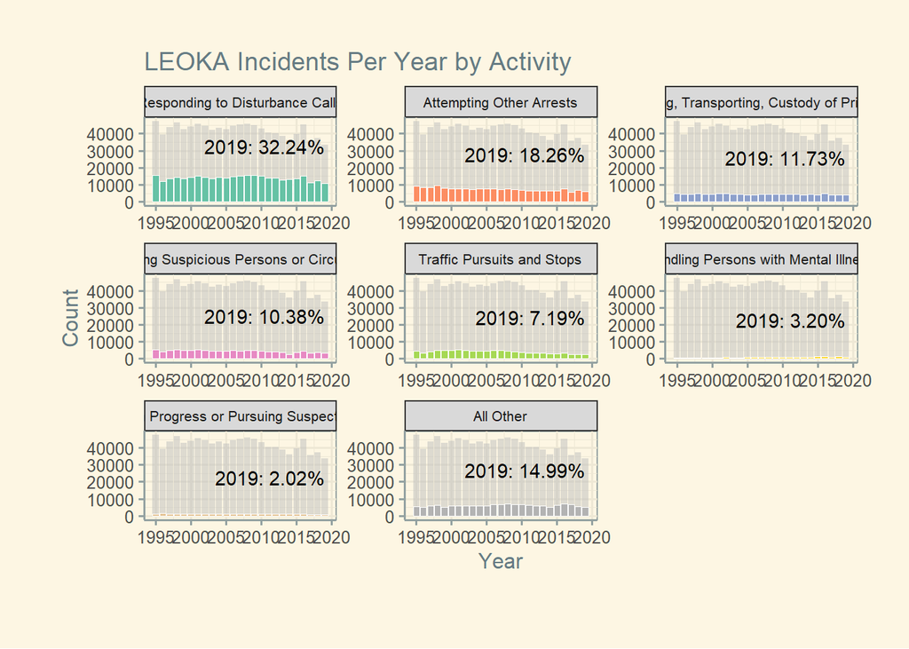

```r
### Comparison ###

# Total vs Activity Type; Col chart
# df1.Act_Yr (percentageActivitiesByYear.csv)

v1 <-
ggplot(data = df1.Act_Yr, aes(x = DATA_YEAR, y = activityTotals)) +
  geom_bar(data = df1.Act_Yr_bg, stat = "identity",
           fill = "grey", alpha = .5, aes(y = activityTotals)) +
  geom_bar(stat = "identity", color = "white", size = 0.1,
           aes(y = activityTotals, fill = ACTIVITY_NAME)) +
  facet_wrap(~ factor(ACTIVITY_NAME, levels = df1.flevels),
        ncol = 3, scales = "free") +
  geom_text(data = df1.Act_Yr_ss, vjust=-2, hjust=1,
            aes(label = sprintf("2019: %1.2f%%", 100*ratio))) +
  labs(title = "LEOKA Incidents Per Year by Activity",
       x = "Year", y = "Count") +
  theme_solarized() +
  theme(legend.position = "none",
        plot.title = element_text(hjust = 0),
        strip.text.x = element_text(size = 8)) +
  scale_fill_brewer(palette = "Set2") +
  theme(plot.margin=unit(c(1,1,1.5,1.2),"cm"))
v1
```

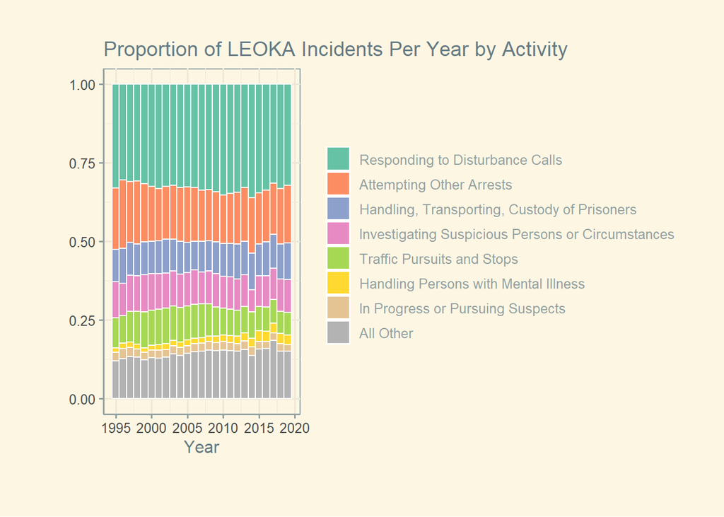

```r
# Proportion stacked

v2 <-
ggplot(data = df1.Act_Yr,
       aes(x = DATA_YEAR, y = activityTotals, fill = ACTIVITY_NAME)) +
  geom_bar(position="fill", stat="identity", width=1, color = "white") +
  labs(title = "Proportion of LEOKA Incidents Per Year by Activity",
       x = "Year", y = "") +
  theme_solarized() +
  scale_fill_brewer(palette = "Set2") +
  theme(plot.title = element_text(hjust = 0), legend.title = element_blank()) +
  theme(plot.margin=unit(c(1,1,1.5,1.2),"cm"))
v2
```

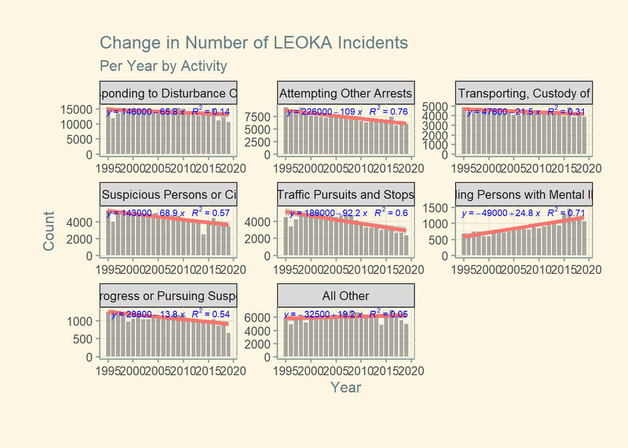

```r
# Activities Change over time; % change facets
# df1.Act_Yr (percentageActivitiesByYear.csv)

my.formula <- y ~ x
v3 <-
ggplot(data = df1.Act_Yr, aes(x = DATA_YEAR, y = activityTotals, )) +
  geom_bar(stat = "identity", color = "white", size = 0.1, alpha = 0.5,
           aes(y = activityTotals)) +
  geom_smooth(method = lm, size = 1.5, show.legend = FALSE,
              aes(color = "orange3")) +
  facet_wrap(~ factor(ACTIVITY_NAME, levels = df1.flevels),
             ncol = 3, scales = "free") +
  labs(title = "Change in Number of LEOKA Incidents",
       subtitle = "Per Year by Activity",
       x = "Year", y = "Count") +
  stat_poly_eq(formula = my.formula, color = "blue", size = 2.5,
               label.x = "right", label.y = 1,
               aes(label = paste(..eq.label.., ..rr.label.., sep = "~~~")),
               parse = TRUE) +
  theme_solarized() +
  theme(legend.position = "none", plot.title = element_text(hjust = 0)) +
  theme(plot.margin=unit(c(1,1,1.5,1.2),"cm"))
v3
```

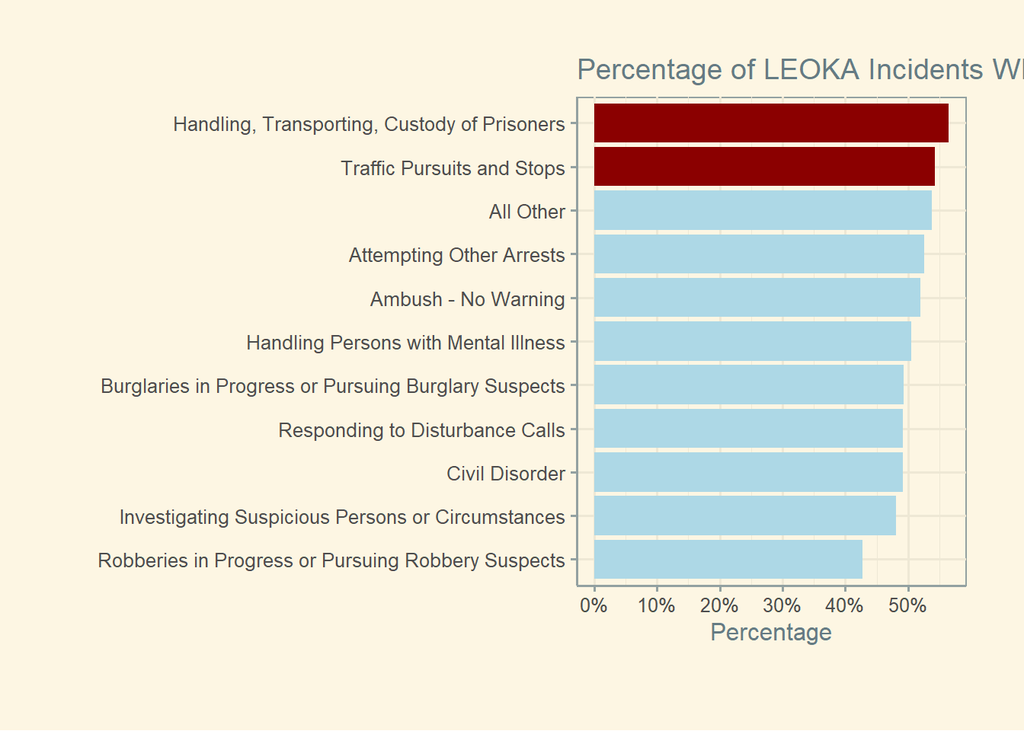

```r
# Alone Percentages by Activity
# df2.Act_Ratio (activitiesWithRatios.csv)

v4 <-
ggplot(data = df2.Act_Ratio, aes(x = reorder(ACTIVITY_NAME, aloneRatio1*1))) +
  geom_bar(stat = "identity", fill = "lightblue", aes(y = aloneRatio1*1)) +
  geom_bar(data = df2.Act_Ratio_ss, stat = "identity",
           fill = "red4", aes(y = aloneRatio1*1)) +
  coord_flip() +
  scale_y_continuous(breaks = seq(0, 0.7, 0.1),
                     labels = paste0(as.character(
                       c("0","10","20","30","40","50","60","70")), "%")) +
  labs(title = "Percentage of LEOKA Incidents Where Officer Was Alone",
       x = "", y = "Percentage") +
  theme_solarized() +
  theme(legend.title = element_blank()) +
  theme(plot.margin=unit(c(1,1,1.5,1.2),"cm"))
v4
```

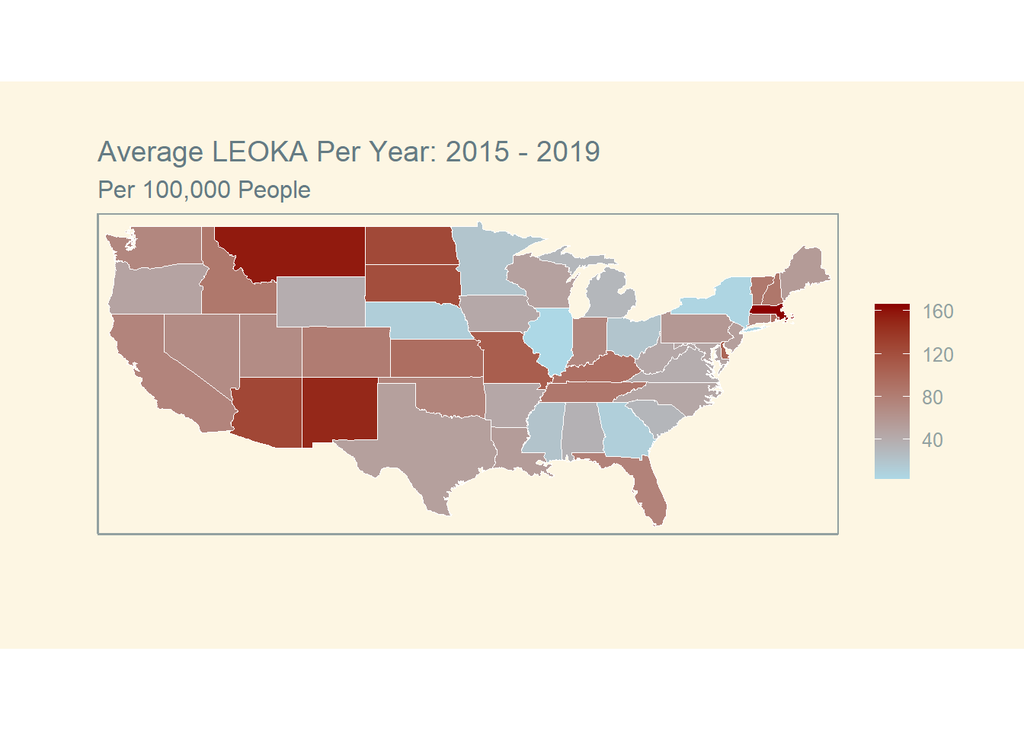

```r
v5 <-
ggplot() +
  geom_polygon(data=MergedStates, aes(x=long, y=lat, group=group,
                    fill = officersAssaulted/Five_Year_Avg_Pop * 100000),
                color="white", size = 0.2)  +
  labs(title = "Average LEOKA Per Year: 2015 - 2019",
       subtitle = "Per 100,000 People") +
  scale_fill_continuous(name="",
                        low = "lightblue", high = "darkred",
                        na.value = "grey50") +
  scale_x_discrete(labels = NULL, breaks = NULL) + labs(x = "") +
  scale_y_discrete(labels = NULL, breaks = NULL) + labs(y = "") +
  theme_solarized() +
  coord_fixed() +
  theme(plot.margin=unit(c(1,1,1.5,1.2),"cm"))
v5
```

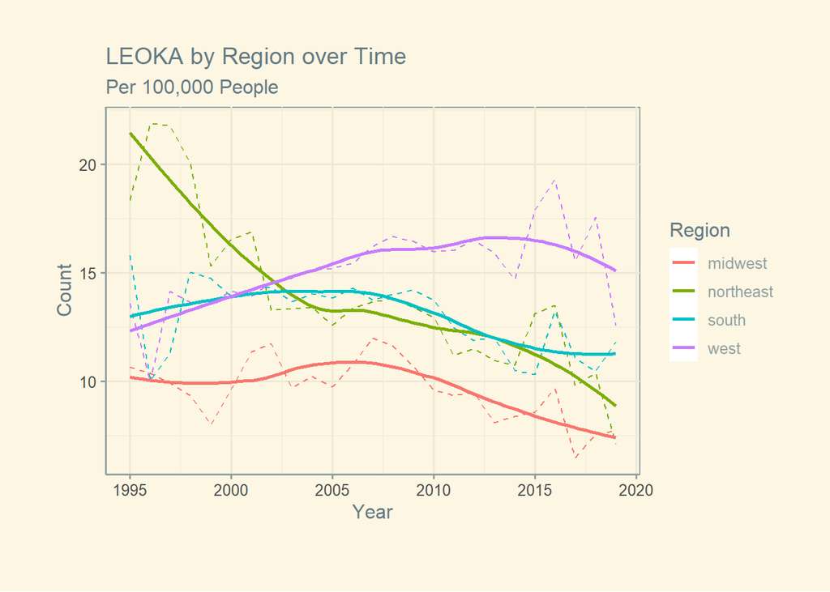

```r
# Region Comparison; Line Chart
# MergedRegions = df5.Aslt_Reg_Yr + df7.US_Pop

v6 <-
  ggplot(MergedRegions,
         aes(x = as.numeric(DATA_YEAR),
             y = officersAssaulted/Five_Year_Avg_Pop * 100000,
             col = region)) +
  geom_line(linetype = "dashed") +
  geom_smooth(formula = "y ~ x", method = "loess",
              se = FALSE, size = 1) +
  labs(title = "LEOKA by Region over Time", subtitle = "Per 100,000 People",
       x = "Year", y = "Count", colour="Region") +
  theme_solarized() +
  theme(plot.margin=unit(c(1,1,1.5,1.2),"cm"))
v6
```

```r
# Save & Compile ----------------------------------------------------------
plots.list = list(v1,v2,v3,v4,v5,v6)
pdf("Visualizations.pdf", paper = "a4r", width = 11.349, height = 8.051)
print(plots.list)
```

```r
dev.off()
```

# 5 Decision Tree

This next analytic technique also functions as an independent script and relies on the output files stored on the shared Github repository. The decision tree answers the questions, “Should a LEOKA incident expected for a call?”

```r
# Library -----------------------------------------------------------------

library(dplyr)
library(rpart)
library(rpart.plot)
```

## 5.1 Read and Clean Data

Another stage of data cleaning was necessary prior to generating the decision tree. This removed unnecesary columns and simplified the values within the `Populations` variable.

```r
# For Decision Trees
Recent_Cats <- read.csv("output/Recent_Cats.csv")
colnames(Recent_Cats)
```

```
## [1] "X"                     "DATA_YEAR"             "REGION_NAME"
## [4] "AGENCY_TYPE_NAME"      "POPULATION_GROUP_DESC" "ACTIVITY_ID"
## [7] "ACTIVITY_NAME"         "assault"
```

```r
Recent_Cats <- Recent_Cats[, -(1:2)]
legend <- unique(Recent_Cats[, 4:5])
Recent_Cats <- Recent_Cats[, -5]


Recent_Cats$ACTIVITY_ID <- as.factor(Recent_Cats$ACTIVITY_ID)

colnames(Recent_Cats)[3] <- "Population"
Recent_Cats$Population <- gsub("Cities ", "", Recent_Cats$Population)
Recent_Cats$Population <- gsub("from ", "", Recent_Cats$Population)
Recent_Cats$Population <- gsub("thru", "-", Recent_Cats$Population)
head(Recent_Cats)
```

```
##   REGION_NAME AGENCY_TYPE_NAME  Population ACTIVITY_ID    assault
## 1       South            Other under 2,500           1 No Assault
## 2       South            Other under 2,500           1 No Assault
## 3       South            Other under 2,500           1 No Assault
## 4       South            Other under 2,500           1 No Assault
## 5       South            Other under 2,500           1 No Assault
## 6       South            Other under 2,500           1 No Assault
```

## 5.2 Analysis

A decision tree was built to predict assault probabilities based on four attributes: Region, Agency Type (e.g., state law enforcement, university police, etc), city population, and activity. Only two attributes contributed to the decision tree: Population (over or under 25k people) and activity. After running the model and determining the population split at 25k people, the values were renamed for ease of visualization. This adjustment did not affect the model outcome.

```r
# As per pg 207, set the minimum observations to 10% of the dataset size.
observations <- nrow(Recent_Cats)*0.1
nrow(Recent_Cats)*0.10
```

```
## [1] 33274
```

```r
colnames(Recent_Cats)
```

```
## [1] "REGION_NAME"      "AGENCY_TYPE_NAME" "Population"       "ACTIVITY_ID"
## [5] "assault"
```

```r
# Run, view, and plot model.
fit <- rpart(assault ~ .,
             data = Recent_Cats,
             method = "class",
             control = rpart.control(minsplit = observations),
             parms = list(split = "information"))
summary(fit)
```

```
## Call:
## rpart(formula = assault ~ ., data = Recent_Cats, method = "class",
##     parms = list(split = "information"), control = rpart.control(minsplit = observations))
##   n= 332740
##
##           CP nsplit rel error    xerror        xstd
## 1 0.05288056      0 1.0000000 1.0000000 0.004671941
## 2 0.01000000      2 0.8942389 0.8942389 0.004450035
##
## Variable importance
##  Population ACTIVITY_ID
##          79          21
##
## Node number 1: 332740 observations,    complexity param=0.05288056
##   predicted class=No Assault  expected loss=0.1210254  P(node) =1
##     class counts: 40270 292470
##    probabilities: 0.121 0.879
##   left son=2 (53265 obs) right son=3 (279475 obs)
##   Primary splits:
##       Population       splits as  LRLRLLLLR,   improve=17402.950, (0 missing)
##       ACTIVITY_ID      splits as  LLRRLRLLRRL, improve=10097.200, (0 missing)
##       REGION_NAME      splits as  RRRL,        improve= 2338.366, (0 missing)
##       AGENCY_TYPE_NAME splits as  LRRRRRRR,    improve= 1587.674, (0 missing)
##
## Node number 2: 53265 observations,    complexity param=0.05288056
##   predicted class=No Assault  expected loss=0.3983667  P(node) =0.1600799
##     class counts: 21219 32046
##    probabilities: 0.398 0.602
##   left son=4 (30805 obs) right son=5 (22460 obs)
##   Primary splits:
##       ACTIVITY_ID splits as  LLRRLRLLRRL, improve=4726.9300, (0 missing)
##       Population  splits as  L-L-RLRL-,   improve=1977.5600, (0 missing)
##       REGION_NAME splits as  LRLL,        improve= 497.1514, (0 missing)
##
## Node number 3: 279475 observations
##   predicted class=No Assault  expected loss=0.0681671  P(node) =0.8399201
##     class counts: 19051 260424
##    probabilities: 0.068 0.932
##
## Node number 4: 30805 observations
##   predicted class=Assault     expected loss=0.4308716  P(node) =0.09257979
##     class counts: 17532 13273
##    probabilities: 0.569 0.431
##
## Node number 5: 22460 observations
##   predicted class=No Assault  expected loss=0.1641585  P(node) =0.06750015
##     class counts:  3687 18773
##    probabilities: 0.164 0.836
```

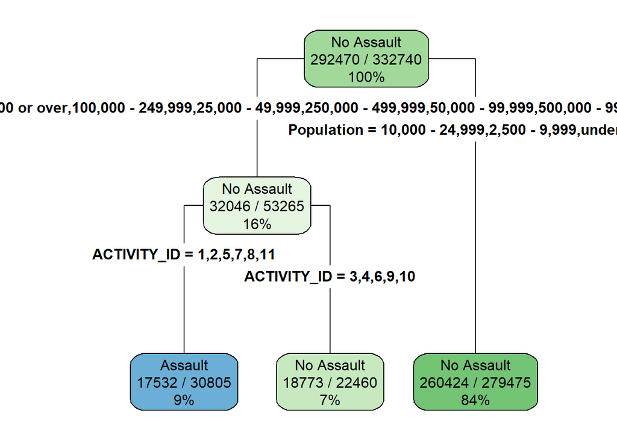

```r
rpart.plot(fit,
           type = 4,
           extra = 102,
           clip.right.labs = FALSE,
           varlen = 0, faclen = 0)
```

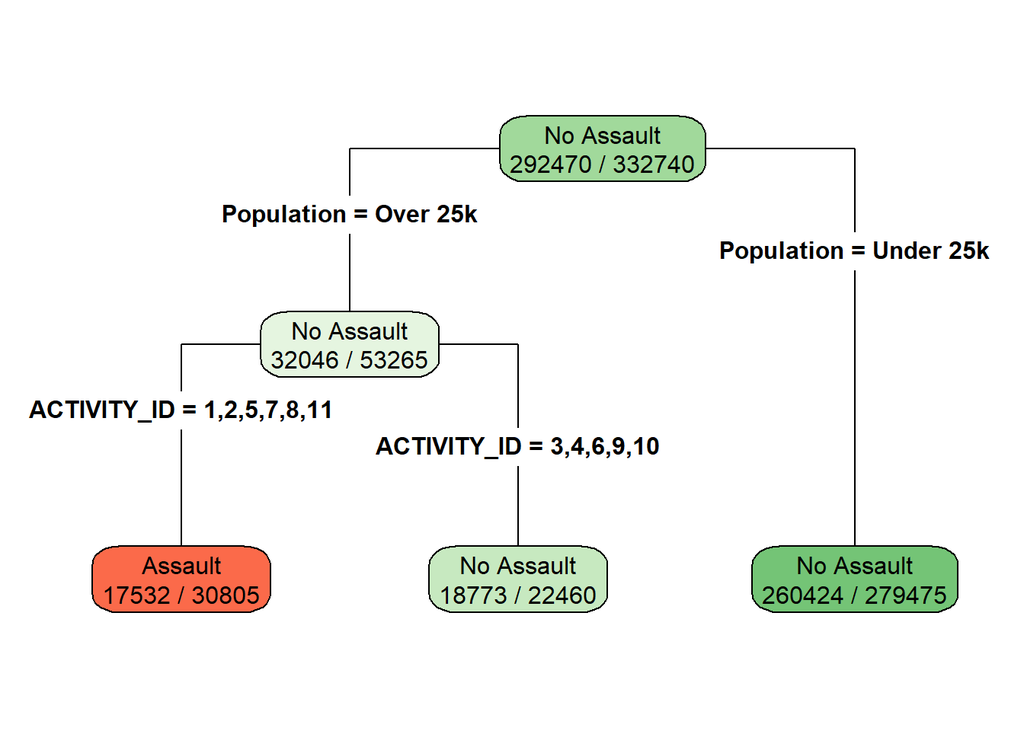

```r
# Because the decision tree splits at "Under 25k" and "Over 25k", I'm changing the factors to reflect this.
Recent_Cats$Population <- factor(Recent_Cats$Population)
levels(Recent_Cats$Population)[levels(Recent_Cats$Population) == "under 2,500"] <- "Under 25k"
levels(Recent_Cats$Population)[levels(Recent_Cats$Population) == "2,500 - 9,999"] <- "Under 25k"
levels(Recent_Cats$Population)[levels(Recent_Cats$Population) == "10,000 - 24,999"] <- "Under 25k"
levels(Recent_Cats$Population)[levels(Recent_Cats$Population) == "25,000 - 49,999"] <- "Over 25k"
levels(Recent_Cats$Population)[levels(Recent_Cats$Population) == "50,000 - 99,999"] <- "Over 25k"
levels(Recent_Cats$Population)[levels(Recent_Cats$Population) == "100,000 - 249,999"] <- "Over 25k"
levels(Recent_Cats$Population)[levels(Recent_Cats$Population) == "250,000 - 499,999"] <- "Over 25k"
levels(Recent_Cats$Population)[levels(Recent_Cats$Population) == "500,000 - 999,999"] <- "Over 25k"
levels(Recent_Cats$Population)[levels(Recent_Cats$Population) == "1,000,000 or over"] <- "Over 25k"



# Rerun the model (results are the same, but labels are cleaner)
fit <- rpart(assault ~ .,
             data = Recent_Cats,
             method = "class",
             control = rpart.control(minsplit = observations),
             parms = list(split = "information"))
rpart.plot(fit,
           type = 4,
           extra = 2,
           clip.right.labs = FALSE,
           varlen = 0,
           faclen = 0,
           box.palette = "RdGn")
```

## 5.3 Most Dangerous Activities

The following table describes the most dangerous activities (in cities with population over 25k people), according to the decision tree above.

```r
legend[c(1, 2, 5, 7, 8, 11), ]
```

```
##        ACTIVITY_ID                                     ACTIVITY_NAME
## 1                1                        Traffic Pursuits and Stops
## 10134            2                   Responding to Disturbance Calls
## 40533            5                          Attempting Other Arrests
## 60799            7      Handling, Transporting, Custody of Prisoners
## 70932            8 Investigating Suspicious Persons or Circumstances
## 101331          11                                         All Other
```